# dplyr

juyoutai

9/30/2019

20191005 横浜市大ハンズオン講習

# 前回の復習

RとRStudioを立ち上げ方法  
必要なパッケージのインストール  
リポジトリって何だった？(CRAN, Bioconductor, GitHub)  
データ解析では可視化が重要 ggplot2（今回は忘れてても大丈夫）

# 本日の内容 データ整形

データを自由自在に操作できるようになる。 Hadleyが無料で公開している[R for data science](https://r4ds.had.co.nz/relational-data.html)

## こんなことありませんか？

- 大容量のデータから必要な箇所だけを抽出したい
- 遺伝子発現行列から特定の遺伝子/サンプルの要素を抽出したい
- 膨大な患者データから目的の患者情報を抽出
- 生データがめちゃくちゃな型でそのままでは解析しにくい

遺伝子発現解析をしているとよく遭遇するこのような課題。しかし数百Mbに及ぶデータからどうやって目的の情報を得るのか？Excelで開いて手作業で頑張るって？それはナンセンス！以下に理由を挙げよう。

1. Excelでは大容量のデータは扱いにくい（実際にやってみそ）
2. 手作業は必ずミスる（筆者も苦い経験あり）
3. 記録が残らない->どこで間違えたのかわからない（おわた）再現性の確保！
4. その操作百万回繰り返せるの？ マクロ？知らん（１００万回死んだ猫）
5. 遺伝子名勝手に変換される問題（Oct4は10月4日じゃないよ！）

おっとExcelの悪口はそこまでだ！（ Excelが便利な時ももちろんある ）

今回はRを使ってデータを自在に操作できるようになろう！  
余談：データベースとSQL

今回学ぶこと  
1. `pipe %>%`演算子  
2. tidy data（整然データ）  
3. tidyrでtidyに変換  
4. dplyrでデータを自由に操作  
5. tidyverseを使った解析の一例

これができると解析の幅が広がる、効率が上がる、、、  
良いことづくしじゃないか！

## `パイプ( %>% )演算子`

magrittrパッケージ。dplyr をロードすれば自動的に使用可能になる。  
`%>% (pipe)`とは何か？モダンなR言語では必要不可欠な魔法の言葉。 x %>% f(a, b)これはf(x, a, b)と一緒  
左辺の結果を右辺の第1引数にする。  
何が便利？  
コードが読みやすい：左から右に流れるので人間の自然な思考に近く可読性が高い  
中間変数などを作る必要ない  
などなど  
慣れるとこれなしではRを使えなくなる。今日も使うよ！

UNIX/Linuxを使える人は | (pipe)と一緒だと思ってください。  
RStudio上であればショートカット`shift+ctrl+M`でいける

注：ggplot2では %>% は使えず+を使う。

いくつか`%>%`を使った練習をしてみましょう。  
適当なコード

```r
library(tidyverse)
str(diamonds)
```

```
## Classes 'tbl_df', 'tbl' and 'data.frame':    53940 obs. of  10 variables:
##  $ carat  : num  0.23 0.21 0.23 0.29 0.31 0.24 0.24 0.26 0.22 0.23 ...
##  $ cut    : Ord.factor w/ 5 levels "Fair"<"Good"<..: 5 4 2 4 2 3 3 3 1 3 ...
##  $ color  : Ord.factor w/ 7 levels "D"<"E"<"F"<"G"<..: 2 2 2 6 7 7 6 5 2 5 ...
##  $ clarity: Ord.factor w/ 8 levels "I1"<"SI2"<"SI1"<..: 2 3 5 4 2 6 7 3 4 5 ...
##  $ depth  : num  61.5 59.8 56.9 62.4 63.3 62.8 62.3 61.9 65.1 59.4 ...
##  $ table  : num  55 61 65 58 58 57 57 55 61 61 ...
##  $ price  : int  326 326 327 334 335 336 336 337 337 338 ...
##  $ x      : num  3.95 3.89 4.05 4.2 4.34 3.94 3.95 4.07 3.87 4 ...
##  $ y      : num  3.98 3.84 4.07 4.23 4.35 3.96 3.98 4.11 3.78 4.05 ...
##  $ z      : num  2.43 2.31 2.31 2.63 2.75 2.48 2.47 2.53 2.49 2.39 ...
```

```r
diamonds %>% str()
```

```
## Classes 'tbl_df', 'tbl' and 'data.frame':    53940 obs. of  10 variables:
##  $ carat  : num  0.23 0.21 0.23 0.29 0.31 0.24 0.24 0.26 0.22 0.23 ...
##  $ cut    : Ord.factor w/ 5 levels "Fair"<"Good"<..: 5 4 2 4 2 3 3 3 1 3 ...
##  $ color  : Ord.factor w/ 7 levels "D"<"E"<"F"<"G"<..: 2 2 2 6 7 7 6 5 2 5 ...
##  $ clarity: Ord.factor w/ 8 levels "I1"<"SI2"<"SI1"<..: 2 3 5 4 2 6 7 3 4 5 ...
##  $ depth  : num  61.5 59.8 56.9 62.4 63.3 62.8 62.3 61.9 65.1 59.4 ...
##  $ table  : num  55 61 65 58 58 57 57 55 61 61 ...
##  $ price  : int  326 326 327 334 335 336 336 337 337 338 ...
##  $ x      : num  3.95 3.89 4.05 4.2 4.34 3.94 3.95 4.07 3.87 4 ...
##  $ y      : num  3.98 3.84 4.07 4.23 4.35 3.96 3.98 4.11 3.78 4.05 ...
##  $ z      : num  2.43 2.31 2.31 2.63 2.75 2.48 2.47 2.53 2.49 2.39 ...
```

```r
1:10
```

```
##  [1]  1  2  3  4  5  6  7  8  9 10
```

```r
sum(1:10)
```

```
## [1] 55
```

```r
1:10 %>% sum()
```

```
## [1] 55
```

使っていくいうちに慣れていく。

## what is tidy data?

tidy data（整然データとも）とはHadley Wickhamが提唱したデータ形式の一つであり、以下の特徴をもつ。  
1. 1つの列は1つの変数  
2. 1つの行は1つの観測  
3. 1つのセルは1つの値

There are three interrelated rules which make a dataset tidy:  
1. Each variable must have its own column.  
2. Each observation must have its own row.  
3. Each value must have its own cell.

なかなか理解しずらい。筆者も最初はわけわからなかった。  
簡単に言うと縦長のデータであり、直感的な人間に理解しやすい形式ではない。しかしR言語はベクトル処理が得意なためこのtidyな型にすると良いことがたくさんある。  
[参考](https://id.fnshr.info/2017/01/09/tidy-data-intro/)

non-tidy（横長）なデータをtidy（縦長）に変換しよう。そのためのパッケージがtidyrである。最近verが新しくなって方法が大きく変わった。従来法はgather()/spread()関数。今後はpivot_longer()/pivot_wider()関数を使っていこう！

ちなみにtidyが全てではない。あくまで一つの方法。

多くの生データはtidyではないのでtidyに整形する必要がある。  
データをtidyに整形してしまえばあとはこっちのものだ。データを自由自在に操作していこう。  
実際にデータを操作しながら学んでいこう。

それでは今まで習ったことを元にいくつか課題に挑戦。  
以下のデータをtidyに変換、元に戻す  
やってみよう  
最悪わからなくても今日は問題ない。

具体例として筆者が実際に以前やった内容を。アフリカ大陸におけるマラリアの発生率のデータ。生データはtidyではないので変換が必要。

```r
# 読み込んで
# tidyに変換、元に戻す
# data from WHO website http://apps.who.int/gho/data/view.main.MALARIAINCIDENCEv?lang=en
# read the malaria data
library(tidyverse)
malaria_incidence <- read_csv("malaria_incidence.csv", skip = 1)
#################
# tidyな型へ
# この場合は除外する列名を指定した
# 古い方法
malaria_incidence_tidy <- tidyr::gather(malaria_incidence, key = Year, value = Incidence, -Country)

#############
# 新しい方法
# tidyr ver1.0.0 new function pivot_longer
malaria_incidence_tidy_pivot <- malaria_incidence %>% tidyr::pivot_longer(-Country,
                                                                   names_to = "Year",
                                                                   values_to = "Incidence")
# pivot_wider
# 元に戻す
malaria_incidence_non_tidy <- malaria_incidence_tidy_pivot %>% tidyr::pivot_wider(names_from = Year,
                                                    values_from = Incidence)

head(malaria_incidence)
```

```
## # A tibble: 6 x 11
##   Country `2017` `2016` `2015` `2014` `2013` `2012` `2011` `2010` `2005`
##   <chr>    <dbl>  <dbl>  <dbl>  <dbl>  <dbl>  <dbl>  <dbl>  <dbl>  <dbl>
## 1 Afghan…   23.0    23    14.2   11.3   8.75  11.8   19.9   15.9   28.9
## 2 Algeria    0       0     0      0     0      0.02   0      0      0.15
## 3 Angola   155.    156.  154.   140.  130.   124.   126.   134.   211.
## 4 Argent…    0       0     0      0     0      0      0      0.07   1.29
## 5 Armenia    0       0     0      0     0      0      0      0      0
## 6 Azerba…    0       0     0      0     0      0.01   0.02   0.24   1.23
## # … with 1 more variable: `2000` <dbl>
```

```r
head(malaria_incidence_tidy)
```

```
## # A tibble: 6 x 3
##   Country     Year  Incidence
##   <chr>       <chr>     <dbl>
## 1 Afghanistan 2017       23.0
## 2 Algeria     2017        0
## 3 Angola      2017      155.
## 4 Argentina   2017        0
## 5 Armenia     2017        0
## 6 Azerbaijan  2017        0
```

```r
head(malaria_incidence_tidy_pivot)
```

```
## # A tibble: 6 x 3
##   Country     Year  Incidence
##   <chr>       <chr>     <dbl>
## 1 Afghanistan 2017      23.0
## 2 Afghanistan 2016      23
## 3 Afghanistan 2015      14.2
## 4 Afghanistan 2014      11.3
## 5 Afghanistan 2013       8.75
## 6 Afghanistan 2012      11.8
```

```r
head(malaria_incidence_non_tidy)
```

```
## # A tibble: 6 x 11
##   Country `2017` `2016` `2015` `2014` `2013` `2012` `2011` `2010` `2005`
##   <chr>    <dbl>  <dbl>  <dbl>  <dbl>  <dbl>  <dbl>  <dbl>  <dbl>  <dbl>
## 1 Afghan…   23.0    23    14.2   11.3   8.75  11.8   19.9   15.9   28.9
## 2 Algeria    0       0     0      0     0      0.02   0      0      0.15
## 3 Angola   155.    156.  154.   140.  130.   124.   126.   134.   211.
## 4 Argent…    0       0     0      0     0      0      0      0.07   1.29
## 5 Armenia    0       0     0      0     0      0      0      0      0
## 6 Azerba…    0       0     0      0     0      0.01   0.02   0.24   1.23
## # … with 1 more variable: `2000` <dbl>
```

malariaのデータをtidyにに変換してみた！  
実際にはここから地図データを合わせてプロットした。

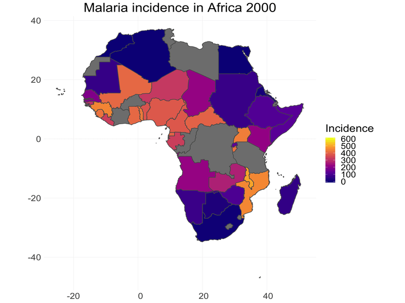

## データ整形

tidy dataにしてしまえばこっちのものだ。自由自在にデータを操作していこう。

最低限以下の関数を押さえて置くだけでだいぶ違う。

- `select()`
- `rename()`
- `filter()`
- `slice()`
- `mutate()`
- `arrange()`
- `group_by()`
- `n_distinct()`
- `summarise()`
- `_join()`

それぞれの関数について見ていこう。 素晴らしい[資料](https://kazutan.github.io/JSSP2018_spring/data_handling.html)があった

```r
####################
# this data explains the amount of apple yield (kg), diameter of trees (mm), cow or not (Grazing)
compensation <- readr::read_csv("compensation.csv") # read the data
compensation2 <- read.csv("compensation.csv")

compensation
```

```
## # A tibble: 40 x 3
##     Root Fruit Grazing
##    <dbl> <dbl> <chr>
##  1  6.22  59.8 Ungrazed
##  2  6.49  61.0 Ungrazed
##  3  4.92  14.7 Ungrazed
##  4  5.13  19.3 Ungrazed
##  5  5.42  34.2 Ungrazed
##  6  5.36  35.5 Ungrazed
##  7  7.61  87.7 Ungrazed
##  8  6.35  63.2 Ungrazed
##  9  4.97  24.2 Ungrazed
## 10  6.93  64.3 Ungrazed
## # … with 30 more rows
```

```r
compensation2
```

```
##      Root  Fruit  Grazing
## 1   6.225  59.77 Ungrazed
## 2   6.487  60.98 Ungrazed
## 3   4.919  14.73 Ungrazed
## 4   5.130  19.28 Ungrazed
## 5   5.417  34.25 Ungrazed
## 6   5.359  35.53 Ungrazed
## 7   7.614  87.73 Ungrazed
## 8   6.352  63.21 Ungrazed
## 9   4.975  24.25 Ungrazed
## 10  6.930  64.34 Ungrazed
## 11  6.248  52.92 Ungrazed
## 12  5.451  32.35 Ungrazed
## 13  6.013  53.61 Ungrazed
## 14  5.928  54.86 Ungrazed
```

[output cut: 26 more lines]

```r
glimpse(compensation)
```

```
## Observations: 40
## Variables: 3
## $ Root    <dbl> 6.225, 6.487, 4.919, 5.130, 5.417, 5.359, 7.614, 6.352,…
## $ Fruit   <dbl> 59.77, 60.98, 14.73, 19.28, 34.25, 35.53, 87.73, 63.21,…
## $ Grazing <chr> "Ungrazed", "Ungrazed", "Ungrazed", "Ungrazed", "Ungraz…
```

```r
glimpse(compensation2)
```

```
## Observations: 40
## Variables: 3
## $ Root    <dbl> 6.225, 6.487, 4.919, 5.130, 5.417, 5.359, 7.614, 6.352,…
## $ Fruit   <dbl> 59.77, 60.98, 14.73, 19.28, 34.25, 35.53, 87.73, 63.21,…
## $ Grazing <fct> Ungrazed, Ungrazed, Ungrazed, Ungrazed, Ungrazed, Ungra…
```

```r
summary(compensation)
```

```
##       Root            Fruit          Grazing
##  Min.   : 4.426   Min.   : 14.73   Length:40
##  1st Qu.: 6.083   1st Qu.: 41.15   Class :character
##  Median : 7.123   Median : 60.88   Mode  :character
##  Mean   : 7.181   Mean   : 59.41
##  3rd Qu.: 8.510   3rd Qu.: 76.19
##  Max.   :10.253   Max.   :116.05
```

```r
summary(compensation2)
```

```
##       Root            Fruit            Grazing
##  Min.   : 4.426   Min.   : 14.73   Grazed  :20
##  1st Qu.: 6.083   1st Qu.: 41.15   Ungrazed:20
##  Median : 7.123   Median : 60.88
##  Mean   : 7.181   Mean   : 59.41
##  3rd Qu.: 8.510   3rd Qu.: 76.19
##  Max.   :10.253   Max.   :116.05
```

```r
# make compensation$Grazing "factor"
compensation$Grazing <- factor(compensation$Grazing, levels = c("Ungrazed", "Grazed"))

# dplyr
# extract from column
# select()
dplyr::select(compensation, Fruit)
```

```
## # A tibble: 40 x 1
##    Fruit
##    <dbl>
##  1  59.8
##  2  61.0
##  3  14.7
##  4  19.3
##  5  34.2
##  6  35.5
##  7  87.7
##  8  63.2
##  9  24.2
## 10  64.3
## # … with 30 more rows
```

```r
dplyr::select(compensation, -Fruit)
```

```
## # A tibble: 40 x 2
##     Root Grazing
##    <dbl> <fct>
##  1  6.22 Ungrazed
##  2  6.49 Ungrazed
##  3  4.92 Ungrazed
##  4  5.13 Ungrazed
##  5  5.42 Ungrazed
##  6  5.36 Ungrazed
##  7  7.61 Ungrazed
##  8  6.35 Ungrazed
##  9  4.97 Ungrazed
## 10  6.93 Ungrazed
## # … with 30 more rows
```

```r
# base R
# this is also convenient(I often use this way...)
# df[row, column]
compensation[, 2]
```

```
## # A tibble: 40 x 1
##    Fruit
##    <dbl>
##  1  59.8
##  2  61.0
##  3  14.7
##  4  19.3
##  5  34.2
##  6  35.5
##  7  87.7
##  8  63.2
##  9  24.2
## 10  64.3
## # … with 30 more rows
```

```r
compensation[, -2]
```

```
## # A tibble: 40 x 2
##     Root Grazing
##    <dbl> <fct>
##  1  6.22 Ungrazed
##  2  6.49 Ungrazed
##  3  4.92 Ungrazed
##  4  5.13 Ungrazed
##  5  5.42 Ungrazed
##  6  5.36 Ungrazed
##  7  7.61 Ungrazed
##  8  6.35 Ungrazed
##  9  4.97 Ungrazed
## 10  6.93 Ungrazed
## # … with 30 more rows
```

```r
# extract from row
# slice()
# extract second row
dplyr::slice(compensation, 2)
```

```
## # A tibble: 1 x 3
##    Root Fruit Grazing
##   <dbl> <dbl> <fct>
## 1  6.49  61.0 Ungrazed
```

```r
# from 2nd to 10th row
dplyr::slice(compensation, 2:10)
```

```
## # A tibble: 9 x 3
##    Root Fruit Grazing
##   <dbl> <dbl> <fct>
## 1  6.49  61.0 Ungrazed
## 2  4.92  14.7 Ungrazed
## 3  5.13  19.3 Ungrazed
## 4  5.42  34.2 Ungrazed
## 5  5.36  35.5 Ungrazed
## 6  7.61  87.7 Ungrazed
## 7  6.35  63.2 Ungrazed
## 8  4.97  24.2 Ungrazed
## 9  6.93  64.3 Ungrazed
```

```r
# non-continuous row
# 2nd, 3rd and 10th row
# c() function makes vector
dplyr::slice(compensation, c(2,3,10))
```

```
## # A tibble: 3 x 3
##    Root Fruit Grazing
##   <dbl> <dbl> <fct>
## 1  6.49  61.0 Ungrazed
## 2  4.92  14.7 Ungrazed
## 3  6.93  64.3 Ungrazed
```

```r
# operator, enzanshi
# == equal
# != not equal
# <, >, >=, <=
# | OR
# & AND
# and more...

# find the rows where it is true that Fruit is >80
dplyr::filter(compensation, Fruit > 80)
```

```
## # A tibble: 9 x 3
##    Root Fruit Grazing
##   <dbl> <dbl> <fct>
## 1  7.61  87.7 Ungrazed
## 2  7.00  80.6 Ungrazed
## 3 10.3  116.  Grazed
## 4  9.04  84.4 Grazed
## 5  8.99  80.3 Grazed
## 6  8.98  82.4 Grazed
## 7  9.84 105.  Grazed
## 8  9.35  98.5 Grazed
## 9  8.53  83.0 Grazed
```

```r
# find the rows where it is true that Fruit is >80 or <20
dplyr::filter(compensation, Fruit > 80 | Fruit < 20)
```

```
## # A tibble: 13 x 3
##     Root Fruit Grazing
##    <dbl> <dbl> <fct>
##  1  4.92  14.7 Ungrazed
##  2  5.13  19.3 Ungrazed
##  3  7.61  87.7 Ungrazed
##  4  7.00  80.6 Ungrazed
##  5  4.43  18.9 Ungrazed
##  6 10.3  116.  Grazed
##  7  9.04  84.4 Grazed
##  8  6.11  15.0 Grazed
##  9  8.99  80.3 Grazed
## 10  8.98  82.4 Grazed
## 11  9.84 105.  Grazed
## 12  9.35  98.5 Grazed
## 13  8.53  83.0 Grazed
```

```r
# assign to an object
many_yields <- dplyr::filter(compensation, Fruit > 80)

head(compensation)
```

```
## # A tibble: 6 x 3
##    Root Fruit Grazing
##   <dbl> <dbl> <fct>
## 1  6.22  59.8 Ungrazed
## 2  6.49  61.0 Ungrazed
## 3  4.92  14.7 Ungrazed
## 4  5.13  19.3 Ungrazed
## 5  5.42  34.2 Ungrazed
## 6  5.36  35.5 Ungrazed
```

```r
# add new column
# mutate()
compensation <- dplyr::mutate(compensation, logFruit = log2(Fruit))
compensation
```

```
## # A tibble: 40 x 4
##     Root Fruit Grazing  logFruit
##    <dbl> <dbl> <fct>       <dbl>
##  1  6.22  59.8 Ungrazed     5.90
##  2  6.49  61.0 Ungrazed     5.93
##  3  4.92  14.7 Ungrazed     3.88
##  4  5.13  19.3 Ungrazed     4.27
##  5  5.42  34.2 Ungrazed     5.10
##  6  5.36  35.5 Ungrazed     5.15
##  7  7.61  87.7 Ungrazed     6.45
##  8  6.35  63.2 Ungrazed     5.98
##  9  4.97  24.2 Ungrazed     4.60
## 10  6.93  64.3 Ungrazed     6.01
## # … with 30 more rows
```

```r
# merit: the original data won't change!




dplyr::select(filter(compensation, Fruit > 80), Root)
```

```
## # A tibble: 9 x 1
##    Root
##   <dbl>
## 1  7.61
## 2  7.00
## 3 10.3
## 4  9.04
## 5  8.99
## 6  8.98
## 7  9.84
## 8  9.35
## 9  8.53
```

```r
# this kind of structure (nested structure or ireko-kouzou) is hard to read
# instead, use %>% (pipe) in R
# magritter package (a part of tidyverse)
# in UNIX/Linux pipe is "|"
# RStudio shortcut key is Shift+Ctr+M
# 出力結果を次の引数として渡す
compensation %>%
  dplyr::filter(Fruit > 80) %>%
  dplyr::select(Root)
```

```
## # A tibble: 9 x 1
##    Root
##   <dbl>
## 1  7.61
## 2  7.00
## 3 10.3
## 4  9.04
## 5  8.99
## 6  8.98
## 7  9.84
## 8  9.35
## 9  8.53
```

```r
# more simple, easy to read the code!

dplyr::summarise(compensation, mean = mean(Fruit))
```

```
## # A tibble: 1 x 1
##    mean
##   <dbl>
## 1  59.4
```

```r
# group_by()
dplyr::summarise(
  group_by(compensation, Grazing),
  mean_fruit = mean(Fruit)
)
```

```
## # A tibble: 2 x 2
##   Grazing  mean_fruit
##   <fct>         <dbl>
## 1 Ungrazed       50.9
## 2 Grazed         67.9
```

```r
# use %>%
compensation %>%
  dplyr::group_by(Grazing) %>%
  dplyr::summarise(mean_fruit = mean(Fruit))
```

```
## # A tibble: 2 x 2
##   Grazing  mean_fruit
##   <fct>         <dbl>
## 1 Ungrazed       50.9
## 2 Grazed         67.9
```

```r
# did you get the same result?
compensation %>%
  dplyr::group_by(Grazing) %>%
  dplyr::summarise(mean_fruit = mean(Fruit),
                   sd_fruit = sd(Fruit))
```

```
## # A tibble: 2 x 3
##   Grazing  mean_fruit sd_fruit
##   <fct>         <dbl>    <dbl>
## 1 Ungrazed       50.9     21.8
## 2 Grazed         67.9     25.0
```

```r
##################
# Exercise
# diamonds data set
diamonds
```

```
## # A tibble: 53,940 x 10
##    carat cut       color clarity depth table price     x     y     z
##    <dbl> <ord>     <ord> <ord>   <dbl> <dbl> <int> <dbl> <dbl> <dbl>
##  1 0.23  Ideal     E     SI2      61.5    55   326  3.95  3.98  2.43
##  2 0.21  Premium   E     SI1      59.8    61   326  3.89  3.84  2.31
##  3 0.23  Good      E     VS1      56.9    65   327  4.05  4.07  2.31
##  4 0.290 Premium   I     VS2      62.4    58   334  4.2   4.23  2.63
##  5 0.31  Good      J     SI2      63.3    58   335  4.34  4.35  2.75
##  6 0.24  Very Good J     VVS2     62.8    57   336  3.94  3.96  2.48
##  7 0.24  Very Good I     VVS1     62.3    57   336  3.95  3.98  2.47
##  8 0.26  Very Good H     SI1      61.9    55   337  4.07  4.11  2.53
##  9 0.22  Fair      E     VS2      65.1    61   337  3.87  3.78  2.49
## 10 0.23  Very Good H     VS1      59.4    61   338  4     4.05  2.39
## # … with 53,930 more rows
```

```r
# get carat and price rows
select(diamonds, carat, price)
```

```
## # A tibble: 53,940 x 2
##    carat price
##    <dbl> <int>
##  1 0.23    326
##  2 0.21    326
##  3 0.23    327
##  4 0.290   334
##  5 0.31    335
##  6 0.24    336
##  7 0.24    336
##  8 0.26    337
##  9 0.22    337
## 10 0.23    338
## # … with 53,930 more rows
```

```r
# use %>%
diamonds %>% select(carat, price)
```

```
## # A tibble: 53,940 x 2
##    carat price
##    <dbl> <int>
##  1 0.23    326
##  2 0.21    326
##  3 0.23    327
##  4 0.290   334
##  5 0.31    335
##  6 0.24    336
##  7 0.24    336
##  8 0.26    337
##  9 0.22    337
## 10 0.23    338
## # … with 53,930 more rows
```

```r
diamonds %>% select(1, 7)
```

```
## # A tibble: 53,940 x 2
##    carat price
##    <dbl> <int>
##  1 0.23    326
##  2 0.21    326
##  3 0.23    327
##  4 0.290   334
##  5 0.31    335
##  6 0.24    336
##  7 0.24    336
##  8 0.26    337
##  9 0.22    337
## 10 0.23    338
## # … with 53,930 more rows
```

```r
# starts_with(), ends_with(), contains()
diamonds %>% select(starts_with("c"))
```

```
## # A tibble: 53,940 x 4
##    carat cut       color clarity
##    <dbl> <ord>     <ord> <ord>
##  1 0.23  Ideal     E     SI2
##  2 0.21  Premium   E     SI1
##  3 0.23  Good      E     VS1
##  4 0.290 Premium   I     VS2
##  5 0.31  Good      J     SI2
##  6 0.24  Very Good J     VVS2
##  7 0.24  Very Good I     VVS1
##  8 0.26  Very Good H     SI1
##  9 0.22  Fair      E     VS2
## 10 0.23  Very Good H     VS1
## # … with 53,930 more rows
```

```r
diamonds %>% select(ends_with("e"))
```

```
## # A tibble: 53,940 x 2
##    table price
##    <dbl> <int>
##  1    55   326
##  2    61   326
##  3    65   327
##  4    58   334
##  5    58   335
##  6    57   336
##  7    57   336
##  8    55   337
##  9    61   337
## 10    61   338
## # … with 53,930 more rows
```

```r
diamonds %>% select(contains("l"))
```

```
## # A tibble: 53,940 x 3
##    color clarity table
##    <ord> <ord>   <dbl>
##  1 E     SI2        55
##  2 E     SI1        61
##  3 E     VS1        65
##  4 I     VS2        58
##  5 J     SI2        58
##  6 J     VVS2       57
##  7 I     VVS1       57
##  8 H     SI1        55
##  9 E     VS2        61
## 10 H     VS1        61
## # … with 53,930 more rows
```

```r
diamonds %>% select(-c(carat, price))
```

```
## # A tibble: 53,940 x 8
##    cut       color clarity depth table     x     y     z
##    <ord>     <ord> <ord>   <dbl> <dbl> <dbl> <dbl> <dbl>
##  1 Ideal     E     SI2      61.5    55  3.95  3.98  2.43
##  2 Premium   E     SI1      59.8    61  3.89  3.84  2.31
##  3 Good      E     VS1      56.9    65  4.05  4.07  2.31
##  4 Premium   I     VS2      62.4    58  4.2   4.23  2.63
##  5 Good      J     SI2      63.3    58  4.34  4.35  2.75
##  6 Very Good J     VVS2     62.8    57  3.94  3.96  2.48
##  7 Very Good I     VVS1     62.3    57  3.95  3.98  2.47
##  8 Very Good H     SI1      61.9    55  4.07  4.11  2.53
##  9 Fair      E     VS2      65.1    61  3.87  3.78  2.49
## 10 Very Good H     VS1      59.4    61  4     4.05  2.39
## # … with 53,930 more rows
```

```r
diamonds %>% select(-c(1, 7))
```

```
## # A tibble: 53,940 x 8
##    cut       color clarity depth table     x     y     z
##    <ord>     <ord> <ord>   <dbl> <dbl> <dbl> <dbl> <dbl>
##  1 Ideal     E     SI2      61.5    55  3.95  3.98  2.43
##  2 Premium   E     SI1      59.8    61  3.89  3.84  2.31
##  3 Good      E     VS1      56.9    65  4.05  4.07  2.31
##  4 Premium   I     VS2      62.4    58  4.2   4.23  2.63
##  5 Good      J     SI2      63.3    58  4.34  4.35  2.75
##  6 Very Good J     VVS2     62.8    57  3.94  3.96  2.48
##  7 Very Good I     VVS1     62.3    57  3.95  3.98  2.47
##  8 Very Good H     SI1      61.9    55  4.07  4.11  2.53
##  9 Fair      E     VS2      65.1    61  3.87  3.78  2.49
## 10 Very Good H     VS1      59.4    61  4     4.05  2.39
## # … with 53,930 more rows
```

```r
diamonds %>% filter(cut == "Ideal")
```

```
## # A tibble: 21,551 x 10
##    carat cut   color clarity depth table price     x     y     z
##    <dbl> <ord> <ord> <ord>   <dbl> <dbl> <int> <dbl> <dbl> <dbl>
##  1  0.23 Ideal E     SI2      61.5    55   326  3.95  3.98  2.43
##  2  0.23 Ideal J     VS1      62.8    56   340  3.93  3.9   2.46
##  3  0.31 Ideal J     SI2      62.2    54   344  4.35  4.37  2.71
##  4  0.3  Ideal I     SI2      62      54   348  4.31  4.34  2.68
##  5  0.33 Ideal I     SI2      61.8    55   403  4.49  4.51  2.78
##  6  0.33 Ideal I     SI2      61.2    56   403  4.49  4.5   2.75
##  7  0.33 Ideal J     SI1      61.1    56   403  4.49  4.55  2.76
##  8  0.23 Ideal G     VS1      61.9    54   404  3.93  3.95  2.44
##  9  0.32 Ideal I     SI1      60.9    55   404  4.45  4.48  2.72
## 10  0.3  Ideal I     SI2      61      59   405  4.3   4.33  2.63
## # … with 21,541 more rows
```

```r
# why below results an error?
# diamonds %>% filter(cut = "Ideal")

diamonds %>% filter(cut == "Ideal" | cut == "Good")
```

```
## # A tibble: 26,457 x 10
##    carat cut   color clarity depth table price     x     y     z
##    <dbl> <ord> <ord> <ord>   <dbl> <dbl> <int> <dbl> <dbl> <dbl>
##  1  0.23 Ideal E     SI2      61.5    55   326  3.95  3.98  2.43
##  2  0.23 Good  E     VS1      56.9    65   327  4.05  4.07  2.31
##  3  0.31 Good  J     SI2      63.3    58   335  4.34  4.35  2.75
##  4  0.3  Good  J     SI1      64      55   339  4.25  4.28  2.73
##  5  0.23 Ideal J     VS1      62.8    56   340  3.93  3.9   2.46
##  6  0.31 Ideal J     SI2      62.2    54   344  4.35  4.37  2.71
##  7  0.3  Ideal I     SI2      62      54   348  4.31  4.34  2.68
##  8  0.3  Good  J     SI1      63.4    54   351  4.23  4.29  2.7
##  9  0.3  Good  J     SI1      63.8    56   351  4.23  4.26  2.71
## 10  0.3  Good  I     SI2      63.3    56   351  4.26  4.3   2.71
## # … with 26,447 more rows
```

```r
diamonds %>% filter(cut %in% c("Ideal", "Good"))
```

```
## # A tibble: 26,457 x 10
##    carat cut   color clarity depth table price     x     y     z
##    <dbl> <ord> <ord> <ord>   <dbl> <dbl> <int> <dbl> <dbl> <dbl>
##  1  0.23 Ideal E     SI2      61.5    55   326  3.95  3.98  2.43
##  2  0.23 Good  E     VS1      56.9    65   327  4.05  4.07  2.31
##  3  0.31 Good  J     SI2      63.3    58   335  4.34  4.35  2.75
##  4  0.3  Good  J     SI1      64      55   339  4.25  4.28  2.73
##  5  0.23 Ideal J     VS1      62.8    56   340  3.93  3.9   2.46
##  6  0.31 Ideal J     SI2      62.2    54   344  4.35  4.37  2.71
##  7  0.3  Ideal I     SI2      62      54   348  4.31  4.34  2.68
##  8  0.3  Good  J     SI1      63.4    54   351  4.23  4.29  2.7
##  9  0.3  Good  J     SI1      63.8    56   351  4.23  4.26  2.71
## 10  0.3  Good  I     SI2      63.3    56   351  4.26  4.3   2.71
## # … with 26,447 more rows
```

```r
diamonds %>% filter(price >= 1000)
```

```
## # A tibble: 39,441 x 10
##    carat cut       color clarity depth table price     x     y     z
##    <dbl> <ord>     <ord> <ord>   <dbl> <dbl> <int> <dbl> <dbl> <dbl>
##  1  0.7  Ideal     E     SI1      62.5    57  2757  5.7   5.72  3.57
##  2  0.86 Fair      E     SI2      55.1    69  2757  6.45  6.33  3.52
##  3  0.7  Ideal     G     VS2      61.6    56  2757  5.7   5.67  3.5
##  4  0.71 Very Good E     VS2      62.4    57  2759  5.68  5.73  3.56
##  5  0.78 Very Good G     SI2      63.8    56  2759  5.81  5.85  3.72
##  6  0.7  Good      E     VS2      57.5    58  2759  5.85  5.9   3.38
##  7  0.7  Good      F     VS1      59.4    62  2759  5.71  5.76  3.4
##  8  0.96 Fair      F     SI2      66.3    62  2759  6.27  5.95  4.07
##  9  0.73 Very Good E     SI1      61.6    59  2760  5.77  5.78  3.56
## 10  0.8  Premium   H     SI1      61.5    58  2760  5.97  5.93  3.66
## # … with 39,431 more rows
```

```r
diamonds %>%
  group_by(cut) %>%
  summarise(meanPrice =  mean(price))
```

```
## # A tibble: 5 x 2
##   cut       meanPrice
##   <ord>         <dbl>
## 1 Fair          4359.
## 2 Good          3929.
## 3 Very Good     3982.
## 4 Premium       4584.
## 5 Ideal         3458.
```

```r
diamonds %>%
  group_by(cut) %>%
  summarise(meanPrice =  mean(price)) %>%
  arrange(meanPrice)
```

```
## # A tibble: 5 x 2
##   cut       meanPrice
##   <ord>         <dbl>
## 1 Ideal         3458.
## 2 Good          3929.
## 3 Very Good     3982.
## 4 Fair          4359.
## 5 Premium       4584.
```

```r
diamonds %>%
  group_by(cut) %>%
  summarise(meanPrice =  mean(price)) %>%
  arrange(desc(meanPrice))
```

```
## # A tibble: 5 x 2
##   cut       meanPrice
##   <ord>         <dbl>
## 1 Premium       4584.
## 2 Fair          4359.
## 3 Very Good     3982.
## 4 Good          3929.
## 5 Ideal         3458.
```

```r
# joinまでは手が回らないか...
# リンク先資料の内容で




##############
```

以上で基本的なデータ操作は終了。これらの基本的なスキルがあると解析が捗る。 stringrによる文字列処理などやってないね…

以下おまけ

### おまけ

ImmGenで公開されているRNA-seqデータから目的の細胞種、遺伝子を抜き出して発現量をプロットしてみる。今日学んだdplyrをたくさん使っている。 筆者も修行中の身なので泥臭いところがたくさん。実際にはもっとスマートにできると思います。。。

```r
# 応用としてGEOから入手したRNA-seqデータを加工して発現量をプロットする
# かなり泥臭い方法なのでもっと賢い方法があることでしょう...
# ImmGen
# RNA-seq data from GSE122108 ImmGen MPN project (https://www.ncbi.nlm.nih.gov/geo/query/acc.cgi?acc=GSE122108)
# extract cDC1, cDC2, pDC columns
library(tidyverse)
data <- read.csv("GSE122108_Gene_count_table.csv", sep = "")
data2 <- readr::read_tsv("GSE122108_Gene_count_table.csv")
# このデータは実はtsvになっている（罠だろ...）
# 以下のコマンドでreadrがどれだけ早いか確認できる
system.time(data <- read.csv("GSE122108_Gene_count_table.csv", sep = ""))
```

```
##    user  system elapsed
##   7.021   0.316   7.390
```

```r
system.time(data2 <- readr::read_tsv("GSE122108_Gene_count_table.csv"))
```

```
##    user  system elapsed
##   1.406   0.096   1.512
```

```r
head(data2)
```

```
## # A tibble: 6 x 415
##   gene_symbol MF.64pLYVEpIIn.… MF.64pLYVEpIIn.… MF.64pLYVEpIIn.…
##   <chr>                  <dbl>            <dbl>            <dbl>
## 1 0610005C13…                1                0                0
## 2 0610006L08…                0                0                0
## 3 0610009B22…               69               96               74
## 4 0610009E02…                0                3                6
## 5 0610009L18…                5               11               13
## 6 0610009O20…               78              103              177
## # … with 411 more variables: MF.64pLYVEpIIp.Ao.1 <dbl>,
## #   MF.64pLYVEpIIp.Ao.2 <dbl>, MF.64pLYVEpIIp.Ao.3 <dbl>,
## #   MF.64pLYVEnIIp.Ao.1 <dbl>, MF.64pLYVEnIIp.Ao.2 <dbl>,
## #   MF.64pLYVEnIIp.Ao.3 <dbl>, MF.PC.44 <dbl>, MF.PC.45 <dbl>,
## #   MF.PC.46 <dbl>, MF.F.PC.1 <dbl>, MF.F.PC.2 <dbl>, MF.F.PC.3 <dbl>,
## #   MF.PC.47 <dbl>, MF.PC.48 <dbl>, MF.PC.49 <dbl>, MF.PC.50 <dbl>,
## #   MF.PC.51 <dbl>, MF.PC.52 <dbl>, EMP.E10.5.YS.1 <dbl>,
## #   EMP.E10.5.YS.2 <dbl>, MF.d6.EB.1 <dbl>, MF.d6.EB.2 <dbl>,
## #   MF.d8.EB.1 <dbl>, MF.d8.EB.2 <dbl>, MF.PC.21 <dbl>,
## #   DC.24p8apXCR1n.Sp.1 <dbl>, DC.24p8apXCR1n.Sp.2 <dbl>,
## #   DC.24p8apXCR1p.Sp.1 <dbl>, DC.24p8apXCR1p.Sp.2 <dbl>,
## #   DC.24p8anXCR1n.Sp.1 <dbl>, DC.24p8anXCR1n.Sp.2 <dbl>,
## #   DC.24p8anXCR1p.Sp.1 <dbl>, DC.24p8anXCR1p.Sp.2 <dbl>,
## #   DC.SigHn.64n11chipBst2n11bp8anRFPn.Sp.2 <dbl>,
## #   DC.SigHn.64n11chipBst2n11bp8anRFPn.Sp.3 <dbl>,
## #   DC.SigHn.64n11chipBst2n11bp8anRFPp.Sp.2 <dbl>,
## #   DC.SigHn.64n11chipBst2n11bp8anRFPp.Sp.3 <dbl>, MF.PC.09 <dbl>,
## #   MF.PC.10 <dbl>, DC.XCR1pSIRPan.Th.1 <dbl>, DC.XCR1pSIRPan.Th.2 <dbl>,
## #   DC.XCR1pSIRPan.Th.3 <dbl>, DC.XCR1pSIRPan.Th.4 <dbl>,
## #   DC.XCR1nSIRPap.Th.1 <dbl>, DC.XCR1nSIRPap.Th.2 <dbl>,
## #   DC.XCR1nSIRPap.Th.3 <dbl>, DC.XCR1nSIRPap.Th.4 <dbl>,
## #   MF.64p.Th.1 <dbl>, MF.64p.Th.2 <dbl>, MF.64p.Th.3 <dbl>,
## #   MF.64p.Th.4 <dbl>, MF.PC.03 <dbl>, MF.PC.04 <dbl>, MF.PC.05 <dbl>,
## #   MF.PC.06 <dbl>, MF.115pICAM2p226n6Cn.PC.1 <dbl>,
## #   MF.115pICAM2p226n6Cn.PC.2 <dbl>, MF.115pICAM2p226n6Cn.PC.3 <dbl>,
## #   MF.115p36p6ClopICAM2n226n.Thio.72h.PC.1 <dbl>,
## #   MF.115p36p6ClopICAM2n226n.Thio.72h.PC.2 <dbl>,
## #   MF.115p36p6ClopICAM2n226n.Thio.72h.PC.3 <dbl>,
## #   MF.115p36p6ClopICAM2n226n.Thio.24h.PC.1 <dbl>,
## #   MF.115p36p6ClopICAM2n226n.Thio.24h.PC.2 <dbl>,
## #   MF.115p36p6ClopICAM2n226n.Thio.24h.PC.3 <dbl>,
## #   Mo.115p6Cp36lopICAM2n226n.Thio.24h.PC.1 <dbl>,
## #   Mo.115p6Cp36lopICAM2n226n.Thio.24h.PC.2 <dbl>,
## #   Mo.115p6Cp36lopICAM2n226n.Thio.24h.PC.3 <dbl>,
## #   Mo.115pICAM2n226n6Cn.Thio.4h.PC.1 <dbl>,
## #   Mo.115pICAM2n226n6Cn.Thio.4h.PC.2 <dbl>,
## #   Mo.115pICAM2n226n6Cn.Thio.4h.PC.3 <dbl>,
## #   Mo.115pICAM2n226n6Cn.Thio.8h.PC.1 <dbl>,
## #   Mo.115pICAM2n226n6Cn.Thio.8h.PC.2 <dbl>,
## #   Mo.115pICAM2n226n6Cn.Thio.8h.PC.3 <dbl>, Mo.6Cp.Bl.6 <dbl>,
## #   Mo.6Cp.Bl.7 <dbl>, Mo.6Cp.Bl.8 <dbl>, Mo.6Cp.Thio.24h.BI.1 <dbl>,
## #   Mo.6Cp.Thio.24h.BI.2 <dbl>, Mo.6Cp.Thio.24h.BI.3 <dbl>,
## #   Mo.6Cp.Thio.72h.BI.1 <dbl>, Mo.6Cp.Thio.72h.BI.2 <dbl>,
## #   Mo.6Cp.Thio.72h.BI.3 <dbl>, Mo.6CpThio.4h.BI.2 <dbl>,
## #   Mo.6CpThio.4h.BI.3 <dbl>, Mo.6CpThio.8h.BI.1 <dbl>,
## #   Mo.6CpThio.8h.BI.2 <dbl>, Mo.6CpThio.8h.BI.3 <dbl>,
## #   DC.pDC.DN.BM.1 <dbl>, DC.pDC.DN.BM.2 <dbl>, DC.pDC.DN.Sp.1 <dbl>,
## #   DC.pDC.DN.Sp.2 <dbl>, DC.pDC.DN.Sp.3 <dbl>, DC.pDC.DP.BM.2 <dbl>,
## #   DC.pDC.DP.BM.3 <dbl>, DC.pDC.SigHp6Cn.BM.2 <dbl>,
## #   DC.pDC.SigHp6Cn.BM.3 <dbl>, DC.pDC.SigHn6Cp.BM.1 <dbl>,
## #   DC.pDC.SigHn6Cp.BM.2 <dbl>, DC.pDC.SigHn6Cp.BM.3 <dbl>,
## #   DC.pDC.SigHn6Cp.Sp.1 <dbl>, …
```

```r
# selectでcDCとpDCの列を抜き出す
data.cDC <- data2 %>%
  dplyr::select(gene_symbol, starts_with("DC.cDC"))
data.pDC <- data2 %>%
  dplyr::select(gene_symbol, contains("pDC.120g8p"))
# joinする
data.DCs <- dplyr::full_join(data.cDC, data.pDC, "gene_symbol")

# 列名を分かりやすいものに変更
# baseで
# dplyr::rename()とか使えばできるんだろうか...
names(data.DCs)[2:12] <- c("cDC1_1", "cDC1_2", "cDC1_3", "cDC2_1", "cDC2_2", "cDC2_3", "cDC2_4",
                              "pDC_1", "pDC_2", "pDC_3", "pDC_4")
names(data.DCs)
```

```
##  [1] "gene_symbol" "cDC1_1"      "cDC1_2"      "cDC1_3"      "cDC2_1"
##  [6] "cDC2_2"      "cDC2_3"      "cDC2_4"      "pDC_1"       "pDC_2"
## [11] "pDC_3"       "pDC_4"
```

```r
str(data.DCs)
```

```
## Classes 'spec_tbl_df', 'tbl_df', 'tbl' and 'data.frame': 52997 obs. of  12 variables:
##  $ gene_symbol: chr  "0610005C13Rik" "0610006L08Rik" "0610009B22Rik" "0610009E02Rik" ...
##  $ cDC1_1     : num  4 0 65 0 5 157 91 8 15 145 ...
##  $ cDC1_2     : num  6 0 67 4 8 142 127 9 23 188 ...
##  $ cDC1_3     : num  8 0 95 4 9 209 221 7 28 191 ...
##  $ cDC2_1     : num  9 0 71 0 0 69 90 5 22 127 ...
##  $ cDC2_2     : num  1 0 35 0 3 77 81 4 11 101 ...
##  $ cDC2_3     : num  1 0 30 3 10 123 77 13 17 101 ...
##  $ cDC2_4     : num  4 0 18 0 4 72 65 5 6 69 ...
##  $ pDC_1      : num  3 0 77 1 6 187 92 24 26 173 ...
##  $ pDC_2      : num  0 0 70 7 5 183 102 27 37 138 ...
##  $ pDC_3      : num  5 0 63 0 6 153 75 2 23 131 ...
##  $ pDC_4      : num  6 3 82 2 25 70 47 16 12 143 ...
```

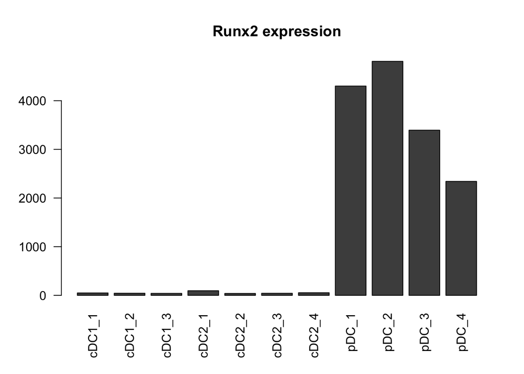

```r
# Runx2について見てみる
# 文字列だからstr_detectでやってあった（半年前の自分凄い、動くからこのまま行こう）
Runx <- data.DCs %>%
  dplyr::filter(str_detect(gene_symbol, "Runx"))
Runx <- Runx[-c(2,4:6),] # Runx family TFのみに
Runx2 <- Runx[2,] # Runx2に絞る
# ちょっとtidyにするの面倒臭い&勉強不足なので一旦baseでplot
# 実際ggplot2はめんどくさいので自分用のデータ探索ならbaseでやってしまうのが楽
# 発表用資料ならggplot2の方が綺麗だけど
barplot(as.matrix(Runx[2,-1]), main = "Runx2 expression", las = 2)
```

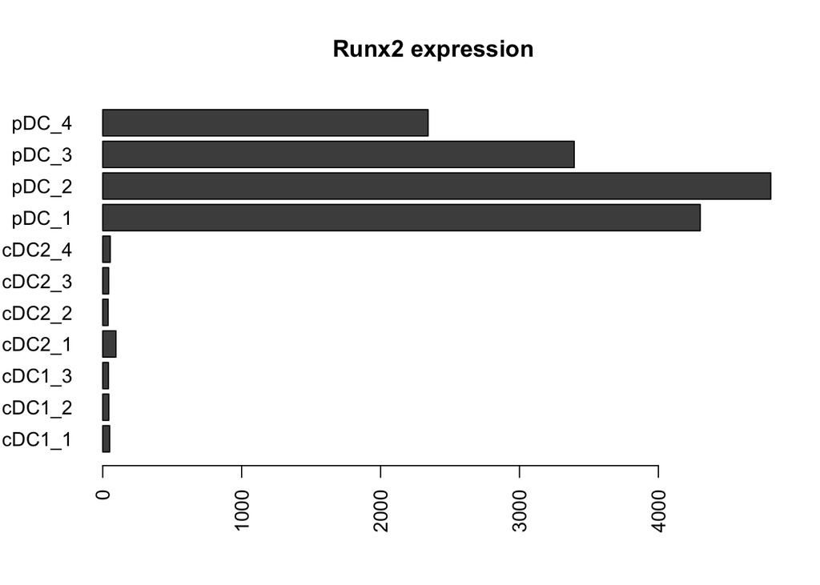

```r
barplot(as.matrix(Runx[2,-1]), main = "Runx2 expression", horiz = T, las = 2)
```

```r
# tidyな型へ整形を頑張る
# 絶対もっと単純な方法あるかと思うが...
# 超絶泥臭いよ！
# pivot_でやる
Runx2_tidy <- Runx2 %>%
  tidyr::pivot_longer(names_to = "Cell", values_to = "expression", -gene_symbol)
# なんとなく列入れ替え
Runx2_tidy <- Runx2_tidy[, c(2,1,3)]
Runx2_tidy
```

```
## # A tibble: 11 x 3
##    Cell   gene_symbol expression
##    <chr>  <chr>            <dbl>
##  1 cDC1_1 Runx2               50
##  2 cDC1_2 Runx2               44
##  3 cDC1_3 Runx2               41
##  4 cDC2_1 Runx2               95
##  5 cDC2_2 Runx2               39
##  6 cDC2_3 Runx2               43
##  7 cDC2_4 Runx2               54
##  8 pDC_1  Runx2             4301
##  9 pDC_2  Runx2             4809
## 10 pDC_3  Runx2             3394
## 11 pDC_4  Runx2             2342
```

```r
Runx2_tidy$Cell <- c("cDC1", "cDC1", "cDC1", "cDC2", "cDC2", "cDC2", "cDC2", "pDC", "pDC", "pDC", "pDC")
Runx2_tidy$Cell
```

```
##  [1] "cDC1" "cDC1" "cDC1" "cDC2" "cDC2" "cDC2" "cDC2" "pDC"  "pDC"  "pDC"
## [11] "pDC"
```

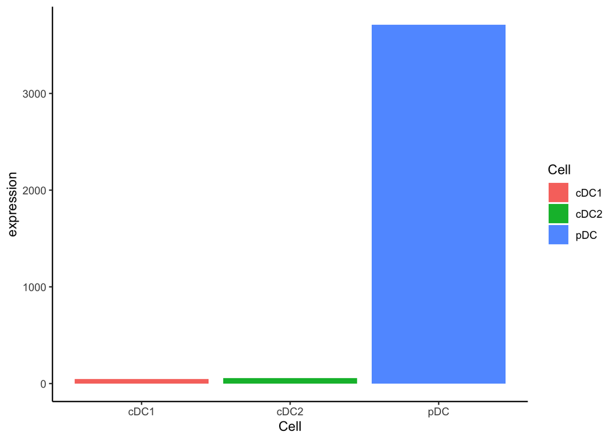

```r
# このあたりはなんなのか？
# 半年前の自分がわからない
ggplot(Runx2_tidy, aes(x = Cell, y = expression, fill = Cell)) +
  stat_summary(aes(fill = Cell), fun.y = "mean", geom = "bar") +
  theme_classic()
```

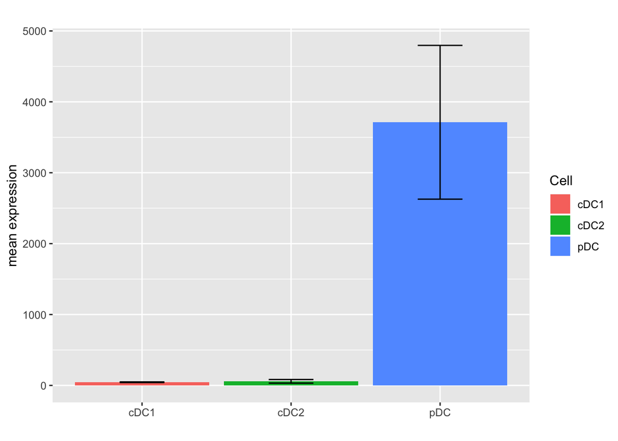

```r
# barplot with error bars
# 統計値を計算
Runx2_sd <- Runx2_tidy %>% group_by(Cell) %>%
  summarize(mean = mean(expression), sd = sd(expression))
# plot
ggplot(Runx2_sd, aes(x = Cell, y = mean, fill = Cell)) +
  geom_bar(stat = "identity") +
  geom_errorbar(aes(ymin = mean - sd, ymax = mean + sd, width = 0.3)) +
  xlab("") + ylab("mean expression") + ggtitle("Runx2 expression") +
  theme(plot.title = element_text(hjust = 5))
```